# Study of personal movement using activity monitoring

Jorge Irazabal

Friday, May 22, 2015

# Introduction

Using devices such as Jawbone Up, Nike FuelBand, and Fitbit it is now possible to collect a large amount of data about personal activity relatively inexpensively. These type of devices are part of the quantified self movement  a group of enthusiasts who take measurements about themselves regularly to improve their health, to find patterns in their behavior, or because they are tech geeks. One thing that people regularly do is quantify how much of a particular activity they do, but they rarely quantify how well they do it. In this project, your goal will be to use data from accelerometers on the belt, forearm, arm, and dumbell of 6 participants. They were asked to perform barbell lifts correctly and incorrectly in 5 different ways.

# Data

The training data for this project are available here: [Training Data](https://d396qusza40orc.cloudfront.net/predmachlearn/pml-training.csv)

The test data are available here: [Test](https://d396qusza40orc.cloudfront.net/predmachlearn/pml-testing.csv)

## Loading and cleanind data

First we go to load the data and clean it

```r
# download.file('https://d396qusza40orc.cloudfront.net/predmachlearn/pml-training.csv','training.csv')
training <- read.csv('training.csv')

# download.file('https://d396qusza40orc.cloudfront.net/predmachlearn/pml-testing.csv','testing.csv')
testing <- read.csv('testing.csv')

dim(training)
```

```
## [1] 19622   160
```

The training data has 19622 observations and 160 features

```r
library(caret)
# Quit irrevelant columns, the first seven columns :user_name raw_timestamp_part_1 raw_timestamp_part_2   cvtd_timestamp new_window num_window
training <- training[,-c(1:7)]
testing <- testing[,-c(1:7)]
# Delete columns with all missing values
training<-training[,colSums(is.na(training)) == 0]
# Delete near zero variance columns
nzvColums <- nearZeroVar(training)
training <- training[, -nzvColums]
dim(training)
```

```
## [1] 19622    53
```

Now, let’s partition training data for cross-validation (60% for training and 40% for test)

```r
trainingPartition <- createDataPartition(y=training$classe, p=0.6, list=FALSE)
trainingTrain <- training[trainingPartition, ]
trainingTest <- training[-trainingPartition, ]
```

# Prediction Models

We use two different prediction methods: Decision Tree and Random Forest

## Decision Tree

```r
# Load libraries
library(rpart)
library(rattle)
library(parallel)
library(doParallel)
#random seed
set.seed(123)
#parallel computing for multi-core
registerDoParallel(makeCluster(detectCores()))

modelTree <- train(classe ~ .,method="rpart",data=trainingTrain)
print(modelTree$finalModel)
```

```
## n= 11776
##
## node), split, n, loss, yval, (yprob)
##       * denotes terminal node
##
##  1) root 11776 8428 A (0.28 0.19 0.17 0.16 0.18)
##    2) roll_belt< 130.5 10785 7447 A (0.31 0.21 0.19 0.18 0.11)
##      4) pitch_forearm< -34.55 926    4 A (1 0.0043 0 0 0) *
##      5) pitch_forearm>=-34.55 9859 7443 A (0.25 0.23 0.21 0.2 0.12)
##       10) magnet_dumbbell_y< 438.5 8327 5962 A (0.28 0.18 0.24 0.19 0.11)
##         20) roll_forearm< 122.5 5200 3064 A (0.41 0.18 0.18 0.17 0.059) *
##         21) roll_forearm>=122.5 3127 2090 C (0.073 0.18 0.33 0.23 0.18) *
##       11) magnet_dumbbell_y>=438.5 1532  758 B (0.033 0.51 0.037 0.23 0.2) *
##    3) roll_belt>=130.5 991   10 E (0.01 0 0 0 0.99) *
```

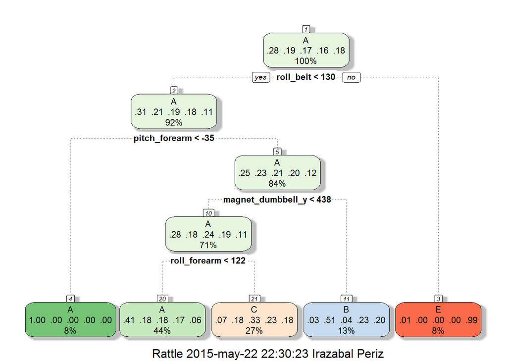

```r
predictTree <- predict(modelTree, trainingTest)

# Plot of the Decision Tree
fancyRpartPlot(modelTree$finalModel)
```

```r
# Show Results
confusionMatrix(predictTree, trainingTest$classe)
```

```
## Confusion Matrix and Statistics
##
##           Reference
## Prediction    A    B    C    D    E
##          A 2010  624  624  563  217
##          B   36  520   53  221  190
##          C  182  374  691  502  385
##          D    0    0    0    0    0
##          E    4    0    0    0  650
##
## Overall Statistics
##
##                Accuracy : 0.4934
##                  95% CI : (0.4823, 0.5045)
##     No Information Rate : 0.2845
##     P-Value [Acc > NIR] : < 2.2e-16
##
##                   Kappa : 0.3383
##  Mcnemar's Test P-Value : NA
##
## Statistics by Class:
##
##                      Class: A Class: B Class: C Class: D Class: E
## Sensitivity            0.9005  0.34256  0.50512   0.0000  0.45076
## Specificity            0.6388  0.92099  0.77725   1.0000  0.99938
## Pos Pred Value         0.4978  0.50980  0.32381      NaN  0.99388
## Neg Pred Value         0.9417  0.85379  0.88148   0.8361  0.88988
## Prevalence             0.2845  0.19347  0.17436   0.1639  0.18379
## Detection Rate         0.2562  0.06628  0.08807   0.0000  0.08284
## Detection Prevalence   0.5147  0.13000  0.27199   0.0000  0.08335
## Balanced Accuracy      0.7696  0.63177  0.64118   0.5000  0.72507
```

## Random Forest

```r
# The tree is limited to 100 because the performace is veru slow
modelForest <- train(classe ~ .,method="rf",data=trainingTrain,ntree=100)
print(modelForest)
```

```
## Random Forest
##
## 11776 samples
##    52 predictor
##     5 classes: 'A', 'B', 'C', 'D', 'E'
##
## No pre-processing
## Resampling: Bootstrapped (25 reps)
##
## Summary of sample sizes: 11776, 11776, 11776, 11776, 11776, 11776, ...
##
## Resampling results across tuning parameters:
##
##   mtry  Accuracy   Kappa      Accuracy SD  Kappa SD
##    2    0.9838713  0.9795957  0.003198658  0.004037377
##   27    0.9841547  0.9799556  0.003214895  0.004059294
##   52    0.9723187  0.9649786  0.003929209  0.004973881
##
## Accuracy was used to select the optimal model using  the largest value.
## The final value used for the model was mtry = 27.
```

```r
# Predicting:
predictForest <- predict(modelForest, trainingTest)

# Show Results
confusionMatrix(predictForest, trainingTest$classe)
```

```
## Confusion Matrix and Statistics
##
##           Reference
## Prediction    A    B    C    D    E
##          A 2227    3    0    0    1
##          B    4 1505    5    2    1
##          C    1    9 1355   31    1
##          D    0    1    8 1253    4
##          E    0    0    0    0 1435
##
## Overall Statistics
##
##                Accuracy : 0.991
##                  95% CI : (0.9886, 0.9929)
##     No Information Rate : 0.2845
##     P-Value [Acc > NIR] : < 2.2e-16
##
##                   Kappa : 0.9886
##  Mcnemar's Test P-Value : NA
##
## Statistics by Class:
##
##                      Class: A Class: B Class: C Class: D Class: E
## Sensitivity            0.9978   0.9914   0.9905   0.9743   0.9951
## Specificity            0.9993   0.9981   0.9935   0.9980   1.0000
## Pos Pred Value         0.9982   0.9921   0.9699   0.9897   1.0000
## Neg Pred Value         0.9991   0.9979   0.9980   0.9950   0.9989
## Prevalence             0.2845   0.1935   0.1744   0.1639   0.1838
## Detection Rate         0.2838   0.1918   0.1727   0.1597   0.1829
## Detection Prevalence   0.2843   0.1933   0.1781   0.1614   0.1829
## Balanced Accuracy      0.9985   0.9948   0.9920   0.9862   0.9976
```

## Conclusion

The Confusion Matrix show that the Random Forest algorithm for each of the values is very approximate , whereas in the case of the Decision Tree, values are widely scattered

# Prediction Assignment Submission

We use the random Forest algorithm with the testing data

```r
predictForest <- predict(modelForest, testing)
# Write files for submission
pml_write_files = function(x){
  n = length(x)
  for(i in 1:n){
    filename = paste0("problem_id_",i,".txt")
    write.table(x[i],file=filename,quote=FALSE,row.names=FALSE,col.names=FALSE)
  }
}

pml_write_files(predictForest)
```